# Are residual disease, stage and age associated with platinum resistance?

An analysis-ready dataset from The Cancer Genome Atlas ovarian cancer project

# Coversheet

**Show coversheetHide coversheet**

[figure not shown]

Coversheet

# Abstract

**Background.** Platinum resistance guides retreatment in ovarian cancer, but TCGA-OV holds no documented resistance outcome. This report derived platinum status from dated records with a six-month rule and tested its association with residual disease, stage and age.

**Methods.** TCGA-OV clinical tables (GDC release 46.0) were quality-assessed. Resistance was a new tumour event within 183 days of the last first-line platinum dose. Outcomes were validated against the TCGA Clinical Data Resource and cBioPortal, and logistic regression was fitted.

**Results.** Of 491 first-line patients, 366 were modelled and 105 (28.7%) were resistant. Validation targets were met (kappa 0.966). Residual disease of 1 to 10 mm (odds ratio 3.23 (1.62 to 6.95)) and over 10 mm (2.68 (1.26 to 6.04)) and older age (1.29 per 10 years) were associated with resistance.

**Conclusion.** The dataset suits logistic regression, but the cohort is historical and predominantly white, so the findings are not ready for clinical use.

# 1 Introduction

Ovarian cancer is the 15th most lethal cancer in the UK, causing around 3,900 deaths a year between 2022 and 2024 (1). For 2022 in England, 62.5% of cases with a known stage were advanced (stage III/IV) (2), while the survival rate for 5 years dropped from 95% for those with stage I to ~15% for those with stage IV (3). Approximately 90% of ovarian cancers are epithelial, which is characterised by being a group of five (or more) histological subtypes differing variously from biology to treatment (4). Of all epithelial ovarian cancers, high grade serous cancer (HGSC) is the most common (4) thought to originate in the fallopian tube (4–6).

The standard first-line treatment involves primary cytoreductive (debulking) surgery (4,7). The surgery is then followed by platinum-based chemotherapy, primarily with cisplatin or carboplatin, usually combined with a taxane (4,7). A key term is the platinum-free interval, which signifies the time from the last platinum dose to a sign of tumour recurrence or progression (4). When the interval is longer, a repeat course of treatment has a higher chance of success: in Markman et al.’s study, 27% of women with an interval of 5 to 12 months responded, while 59% responded after an interval of more than two years (8). If progression occurs within six months of the last platinum dose, the disease is classified as platinum-resistant, whereas if recurrence occurs after six months, it is classified as platinum-sensitive (4). Even though the Gynecologic Cancer InterGroup agreed to replace the then standard platinum-free interval with a therapy-free interval (9), this study focuses on platinum-based treatment, so it uses the platinum-free interval as the measure of resistance. This interval is best measured as a continuous variable (10), and any cut-off point is a convention, so this study also looks at 12 months.

Du Bois et al. took 3,126 patients from three randomised trials and found that covariates such as age, performance status, grade, International Federation of Gynecology and Obstetrics (FIGO) stage and histology predicted overall survival (OS) independently of residual disease (11). Complete resection gave the longest progression-free survival and OS, ahead of residual disease of 1 to 10 mm and over 10 mm. However, neither endpoint shows whether the cancer went on to become platinum-resistant.

The Cancer Genome Atlas (TCGA) is a publicly funded project that maps the major genetic changes causing cancer (12). It has profiled and collected clinical data for over 30 cancer types from many tissue source sites (12), and one of its ovarian cancer studies analysed 489 HGSC tumours (13). The clinical tables are open access (14) but vary in quality (15). Liu et al. (16) identified short follow-up, changing recording rules, mixed staging editions and impossible codes such as grade IV ovarian disease (mostly completeness and conformance problems in Kahn’s terms (17)), and they cleaned the data into four survival outcomes, all recommended for ovarian cancer.

Liu et al.’s Clinical Data Resource (CDR) holds no treatment history, and thus cannot show how patients responded to platinum-based treatment (16). Even though cBioPortal provides a platinum status label (sensitive, resistant or too early), the rule that creates it is not recorded in the downloaded data. Nonetheless, it has been used as an outcome, for example to build a resistance predictor on 287 TCGA patients (18). The aim of this report is to build an analysis-ready dataset that derives platinum resistance from dated treatment and disease recurrence records with a stated six-month rule, and to record every patient left out.

**Research question.** Among patients given first-line platinum, are residual disease, stage and age associated with platinum resistance, and does the association hold at a 12-month cut-off?

# 2 Methods

## 2.1 Research question and analytical method

The cohort studied involved patients who started platinum-based treatment within 180 days of diagnosis. Residual disease, FIGO stage group and age at diagnosis were the factors that were tested against platinum resistance. A patient was classed as resistant if their platinum-free interval was shorter than 183 days (six calendar months), meaning a new tumour event occurred less than 183 days after the last first-line dose, or before it. A patient was classed as sensitive if the interval was longer, or if they had 183 days of follow-up without an event. Since the outcome is binary, I chose logistic regression as the method. The dataset fits this method, as it has one row per patient, an outcome derived from dated records, covariates that are fixed before the outcome window, and about 21 events per parameter.

## 2.2 Data sources and provenance

The TCGA-OV clinical tables (Biospecimen Core Resource (BCR) Biotab, release 46.0) were downloaded from the Genomic Data Commons (GDC) on 11 November 2026 with TCGAbiolinks (19), and a checksum was recorded for each file. Two published resources were used only for validation of the data. The CDR (16) provides curated OS and progression-free interval (PFI) for the same 587 patients (OS missing for 2). The cBioPortal study ov_tcga_pub (13,20,21) provides a platinum status label (sensitive, resistant or too early) for 345 patients. Both were linked on the patient barcode.

## 2.3 Governance and safety

All sources are open access, and the GDC allows their use in publications when proper accreditation is given (14). The Five Safes (22) guided how the data were handled throughout the study. The TCGA patient barcodes are the only identifiers in the dataset and all times are recorded as days from diagnosis, so the risk of identifying anyone is low. The repository does not include raw data or the intermediate files derived from them, and the report itself contains only counts, summaries and model estimates.

## 2.4 Data assessment approach

Each of the tables was profiled for various attributes like size, patient coverage and TCGA placeholders such as [Not Available], which were set to missing. Quality checks followed the categories of Kahn et al. (17). Conformance problems included label rows under each header, which meant removing the first two rows of every table, and numbers stored as text. Completeness was assessed further on key patient fields. A range of plausibility checks flagged events after death, negative days, recurrence before the last platinum dose and a few unexpected tumour grade codes (G4 or GB). The vital status conflicted for 47 patients, who were recorded as dead on a follow-up form but alive on the patient form. Finally, implausible values were flagged rather than removed.

## 2.5 Phenotype definitions and analysis-ready dataset design

Each record (row) is attributed to one patient, with day 0 at diagnosis. Both OS and PFI were rebuilt to check the forms and joins against the CDR. Their follow-up and new tumour event days also feed into the platinum status. First-line platinum treatment was identified from 163 free-text drug names, classified in a lookup table (drug_lookup.csv) and checked individually, row by row. Of the 503 patients given platinum, 483 started within 90 days, so the 180-day cut-off affects only a few patients. There are six ordered rules (phenotypes.md) that assign platinum status, and patients who have no end-date, too little follow-up or who died without recurrence are not classified. Residual disease was grouped as none, 1 to 10 mm or over 10 mm, and stage as I to II, III (reference, the largest group) or IV. Lastly, age was entered per 10 years. The R0 to RX residual field was not taken into consideration because it was missing for the overwhelming majority of the cohort, and the therapy-free interval (9) was not needed, because the focus of this study is specifically treatment with platinum-based drugs, and the platinum part of that interval is the platinum-free interval itself. For all the specifications, see docs/phenotypes.md, docs/data_dictionary.csv and docs/dataset_metadata.md.

## 2.6 Validation and sensitivity analyses

Validation was taken into consideration by setting agreement targets before any CDR outcome value was viewed, and by adding four expected differences between the CDR and this rebuild before the comparison ran. Both are located in docs/validation_plan.md. OS and PFI were compared with the CDR on event agreement, and OS time on agreement within 30 days. Platinum status was compared with cBioPortal using Cohen’s kappa, because most patients are sensitive, so the two labels would often agree by chance alone. The target of 0.61 marks substantial agreement (23). S1 refits the model at 12 months (24). S2 compares first-line patients in and out of the model. Finally, the model is refitted without the 29 patients in the model whom the CDR marks as redacted, for which the CDR gives no reason.

## 2.7 Reproducibility

Running run_all.R checks the raw files against their recorded checksums, then runs the numbered scripts in order, each in a new environment. A full rebuild from the raw data has been tested in multiple clean R sessions.

# 3 Results

## 3.1 The analysis-ready dataset

The dataset has one row for each of the 587 TCGA-OV patients and 36 columns. Of the 587, 491 started platinum within 180 days of diagnosis. I then excluded from the model 36 with no recorded last dose, 53 who had too little follow-up or died without a recurrence, and 36 missing age, stage or residual disease. That left 366 patients in the model, 105 of whom (28.7%) were platinum-resistant. The CDR (16) marks 45 patients as redacted. Apart from those, very few records were flagged: 11 patients had a recurrence before their last platinum dose and 3 had unexpected tumour grade codes (G4 or GB).

## 3.2 Validation

All four targets were met (Table 1).

**Against the CDR**

- OS events agreed for 584 of the 585 patients in both sources. The exception, recorded as dead with no death day, was one of the differences predicted before the comparison (docs/validation_plan.md).
- Out of the patients with matching events, 2 had no survival time in one source and 3 differed by more than 30 days.

**Against cBioPortal**

- Platinum status agreed for 273 of 277 patients.
- All four disagreements were resistant here and sensitive in cBioPortal: three recurred 101 to 154 days after their last recorded dose and one before it, which is resistance under the six-month rule, so the difference most likely lies in cBioPortal’s unrecorded rule.

Table 1. Validation against targets set before the comparisons were run

| Check | Target | Achieved | Target met |
| --- | --- | --- | --- |
| OS event agreement with the CDR | 0.95 | 0.998 | yes |
| OS time within 30 days (matching events) | 0.90 | 0.995 | yes |
| PFI event agreement with the CDR | 0.85 | 0.998 | yes |
| Platinum status: Cohen’s kappa against cBioPortal (277 patients) | 0.61 | 0.966 | yes |

## 3.3 Model

Residual disease had the strongest association with resistance (Figure 1). Compared with no macroscopic residual disease, the odds ratio was 3.23 (1.62 to 6.95) for 1 to 10 mm and 2.68 (1.26 to 6.04) for over 10 mm. The intervals overlap widely, so no gradient with size is shown. Also, each 10 years of age was associated with higher odds, 1.29 (1.05 to 1.61). Finally, stage IV did not differ significantly from stage III, 0.82 (0.42 to 1.56). Stage I to II had lower odds, 0.18 (0.01 to 0.94), but only 1 of its 22 patients was resistant, hence the very wide interval.

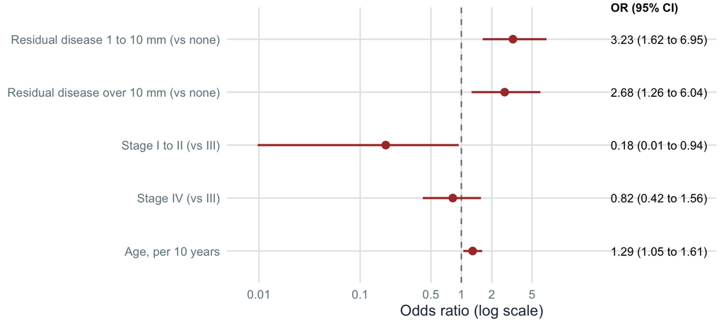

Figure 1. Odds ratios for platinum resistance at six months, with 95% confidence intervals (366 patients, 105 resistant). Values to the right of 1 mean higher odds of resistance; the axis is on a log scale.

## 3.4 Sensitivity analyses

- **S1: 12-month cut-off** (356 patients, 181 resistant). Both residual disease and age kept their direction with smaller odds ratios, at 2.08 (1.20 to 3.68) for 1 to 10 mm and 1.24 (1.02 to 1.50) per 10 years.
- **Without the redacted patients.** Leaving out the 29 redacted patients made little difference: 3.06 (1.52 to 6.65) for 1 to 10 mm and 1.32 (1.05 to 1.66) for age.
- **S2: patients left out (Table 2).** The 125 first-line patients left out of the model were similar in age, stage and race but were diagnosed on average about 2 years later.

Table 2. Patients on first-line platinum in the model and left out (S2)

|  | In the model | Left out |
| --- | --- | --- |
| Patients | 366 | 125 |
| Mean age (years) | 58.6 | 60.1 |
| Stage IV (%) | 15 | 16.9 |
| No residual disease (%) | 24.3 | 19.5 |
| White, of those with race recorded (%) | 89.8 | 89.9 |
| Died (%) | 63.4 | 38.4 |
| Median overall survival (days) | 1212.5 | 346 |
| Mean year of diagnosis | 2003.3 | 2005.5 |

# 4 Conclusion

## 4.1 Fitness for the method

This dataset has been made fit for a logistic regression of platinum resistance, albeit with caveats. When checked, the platinum rule reproduced the cBioPortal label with a kappa of 0.966. This confirms that the method works, but not necessarily that the data are correct, because both use the same TCGA records and a shared error would not be caught. The patients have flags and are not removed, so `in_model` defines the cohort. The flags allow further exclusions, including the 45 the CDR marks as redacted.

## 4.2 Uncertainty in the outcome

The platinum-free interval is best used as a continuous measure (10), thus six months is more of a convention than a real cut-off point. At the 12-month point, both residual disease and age kept their directions, but stage IV did not. A death with tumour but no recorded new tumour event does not count as platinum resistance. But a late end-date leads to a shorter interval and pushes the patient towards platinum resistance.

## 4.3 Selection and representativeness

The main source of bias is the selection process. Firstly, over a quarter of first-line patients (125 of 491) did not qualify because of missing end-dates, short follow-up and/or missing covariates. They were also diagnosed in later calendar years, which led to their shorter observed survival. As a result, the model cohort leaned more towards those who were diagnosed earlier and followed for longer. Race records were missing for 31 patients, and out of the 556 with their race recorded, 498 (89.6%) were white, a heavier skew than the 77% reported across 5,729 samples from ten TCGA tumour types by Spratt et al. (25). Finally, the patient cohort was diagnosed between the years of 1992 and 2013. That means that the treatment is representative of that period, and the findings may not apply to other groups or to current care.

## 4.4 Governance and FAIR

This dataset carries little to no risk. Under the Five Safes (22), the key risk is in outputs. This is where small cells such as the single resistant patient at stage I to II are reported, though these values are already public.

In regard to the FAIR principles (findable, accessible, interoperable and reusable), the dataset has a fixed name, a source release (GDC 46.0) and a metadata file, and can be rebuilt by anyone using the open GDC data.

## 4.5 Implications for care

Defining a patient’s platinum status helps clinicians judge which woman is likely to benefit from further platinum-based treatment when her cancer comes back (8). Nonetheless, the cohort is historical and predominantly white, and the results show associations rather than predictions, making them currently unfit for clinical use.

## 4.6 Future work

Future work could include:

- modelling the platinum-free interval as a continuous measure, as Bookman et al. recommend (10), or even as a time-to-event outcome;
- potentially imputing residual disease for the 35 classified patients who were missing it;
- adding other factors such as BRCA mutation status (9) or homologous recombination status.

# References

**Show reference listHide reference list**

1.

Cancer Research UK. Ovarian cancer mortality statistics. Cancer Research UK [Internet]. [cited 2026 Nov 17]. Available from: https://www.cancerresearchuk.org/health-professional/cancer-statistics/statistics-by-cancer-type/ovarian-cancer/mortality

2.

Cancer Research UK. Early Diagnosis Hub. Cancer Research UK [Internet]. [cited 2026 Nov 17]. Available from: https://crukcancerintelligence.shinyapps.io/EarlyDiagnosis/

3.

Cancer Research UK. Ovarian cancer survival. Cancer Research UK [Internet]. [cited 2026 Nov 17]. Available from: https://www.cancerresearchuk.org/about-cancer/ovarian-cancer/survival

4.

Matulonis UA, Sood AK, Fallowfield L, Howitt BE, Sehouli J, Karlan BY. Ovarian cancer. Nat Rev Dis Primers. 2016 Aug;2(1):16061. doi:10.1038/nrdp.2016.61

5.

Kindelberger DW, Lee Y, Miron A, Hirsch MS, Feltmate C, Medeiros F, et al. Intraepithelial carcinoma of the fimbria and pelvic serous carcinoma: Evidence for a causal relationship. Am J Surg Pathol. 2007 Feb;31(2):161–9. doi:10.1097/01.pas.0000213335.40358.47

6.

Labidi-Galy SI, Papp E, Hallberg D, Niknafs N, Adleff V, Noe M, et al. High grade serous ovarian carcinomas originate in the fallopian tube. Nat Commun. 2017 Oct;8(1):1093. doi:10.1038/s41467-017-00962-1

7.

Lheureux S, Gourley C, Vergote I, Oza AM. Epithelial ovarian cancer. Lancet. 2019 Mar;393(10177):1240–53. doi:10.1016/S0140-6736(18)32552-2

8.

Markman M, Rothman R, Hakes T, Reichman B, Hoskins W, Rubin S, et al. Second-line platinum therapy in patients with ovarian cancer previously treated with cisplatin. J Clin Oncol. 1991 Mar;9(3):389–93. doi:10.1200/JCO.1991.9.3.389

9.

Wilson MK, Pujade-Lauraine E, Aoki D, Mirza MR, Lorusso D, Oza AM, et al. Fifth Ovarian Cancer Consensus Conference of the Gynecologic Cancer InterGroup: Recurrent disease. Ann Oncol. 2017 Apr;28(4):727–32. doi:10.1093/annonc/mdw663

10.

Bookman MA, Okamoto A, Stuart G, Yanaihara N, Aoki D, Bacon M, et al. Harmonising clinical trials within the Gynecologic Cancer InterGroup: Consensus and unmet needs from the Fifth Ovarian Cancer Consensus Conference. Ann Oncol. 2017 Nov;28(Suppl 8):viii30–5. doi:10.1093/annonc/mdx449

11.

du Bois A, Reuss A, Pujade-Lauraine E, Harter P, Ray-Coquard I, Pfisterer J. Role of surgical outcome as prognostic factor in advanced epithelial ovarian cancer: A combined exploratory analysis of 3 prospectively randomized phase 3 multicenter trials: By the Arbeitsgemeinschaft Gynaekologische Onkologie Studiengruppe Ovarialkarzinom (AGO-OVAR) and the Groupe d’Investigateurs Nationaux Pour les Etudes des Cancers de l’Ovaire (GINECO). Cancer. 2009 Mar;115(6):1234–44. doi:10.1002/cncr.24149

12.

Tomczak K, Czerwińska P, Wiznerowicz M. The Cancer Genome Atlas (TCGA): An immeasurable source of knowledge. Contemp Oncol (Pozn). 2015;19(1A):A68–77. doi:10.5114/wo.2014.47136

13.

The Cancer Genome Atlas Research Network. Integrated genomic analyses of ovarian carcinoma. Nature. 2011 Jun;474(7353):609–15. doi:10.1038/nature10166

14.

NCI Genomic Data Commons. Are there restrictions on the use of GDC data in publications? NCI Genomic Data Commons [Internet]. [cited 2026 Nov 11]. Available from: https://gdc.cancer.gov/content/are-there-restrictions-use-gdc-data-publications

15.

The Cancer Genome Atlas Research Network, Weinstein JN, Collisson EA, Mills GB, Shaw KRM, Ozenberger BA, et al. The Cancer Genome Atlas Pan-Cancer analysis project. Nat Genet. 2013 Oct;45(10):1113–20. doi:10.1038/ng.2764

16.

Liu J, Lichtenberg T, Hoadley KA, Poisson LM, Lazar AJ, Cherniack AD, et al. An integrated TCGA Pan-Cancer Clinical Data Resource to drive high-quality survival outcome analytics. Cell. 2018 Apr;173(2):400–416.e11. doi:10.1016/j.cell.2018.02.052

17.

Kahn MG, Callahan TJ, Barnard J, Bauck AE, Brown J, Davidson BN, et al. A harmonized data quality assessment terminology and framework for the secondary use of electronic health record data. EGEMS (Wash DC). 2016 Sep;4(1):1244. doi:10.13063/2327-9214.1244

18.

Li Y, Nie Y, Guo H, Guo H, Ha C, Li Y. Establish of an initial platinum-resistance predictor in high-grade serous ovarian cancer patients regardless of homologous recombination deficiency status. Front Oncol. 2022 Mar;12:847085. doi:10.3389/fonc.2022.847085

19.

Colaprico A, Silva TC, Olsen C, Garofano L, Cava C, Garolini D, et al. TCGAbiolinks: An R/Bioconductor package for integrative analysis of TCGA data. Nucleic Acids Res. 2016 May;44(8):e71–1. doi:10.1093/nar/gkv1507

20.

Cerami E, Gao J, Dogrusoz U, Gross BE, Sumer SO, Aksoy BA, et al. The cBio cancer genomics portal: An open platform for exploring multidimensional cancer genomics data. Cancer Discov. 2012 May;2(5):401–4. doi:10.1158/2159-8290.CD-12-0095

21.

Gao J, Aksoy BA, Dogrusoz U, Dresdner G, Gross B, Sumer SO, et al. Integrative analysis of complex cancer genomics and clinical profiles using the cBioPortal. Sci Signal. 2013 Apr;6(269). doi:10.1126/scisignal.2004088

22.

Desai T, Ritchie F, Welpton R. Five Safes: Designing data access for research [Economics Working Paper] [Internet]. Bristol: University of the West of England; 2016 [cited 2026 Nov 19]. Economics Working Paper no.: 1601. Available from: https://uwe-repository.worktribe.com/output/914745

23.

Landis JR, Koch GG. The measurement of observer agreement for categorical data. Biometrics. 1977 Mar;33(1):159–74. doi:10.2307/2529310

24.

Dockery LE, Rubenstein AR, Ding K, Mashburn SG, Burkett WC, Davis AM, et al. Extending the platinum-free interval: The impact of omitting 2nd line platinum chemotherapy in intermediate platinum-sensitive ovarian cancer. Gynecol Oncol. 2019 Nov;155(2):201–6. doi:10.1016/j.ygyno.2019.07.008

25.

Spratt DE, Chan T, Waldron L, Speers C, Feng FY, Ogunwobi OO, et al. Racial/ethnic disparities in genomic sequencing. JAMA Oncol. 2016 Aug;2(8):1070–4. doi:10.1001/jamaoncol.2016.1854